# car-damage-severity-mobilenetv2 avec donnees augmentées

Entrainement du modèle de base avec la création de données augmentées

```python
%%time
# Installations

# pip install tensorflow
# pip install Pillow
# pip install matplotlib
# pip install scikit-learn
# pip install seaborn
# pip install pydot

import time

RecreerRepertoiresImages = False

# Bibliothèques principales
import numpy as np
from pathlib import Path
import os
from PIL import Image
import shutil
import matplotlib.pyplot as plt
from sklearn.metrics import classification_report, confusion_matrix
import seaborn as sns
import json

# TensorFlow et Keras
import tensorflow as tf
from tensorflow import keras
from tensorflow.keras import layers, models, optimizers, callbacks
from tensorflow.keras.applications import MobileNetV2
from tensorflow.keras.utils import image_dataset_from_directory
from tensorflow.keras.applications.mobilenet_v2 import preprocess_input
from tensorflow.keras.preprocessing.image import ImageDataGenerator
from tensorflow.keras.models import clone_model
from tensorflow.keras.utils import plot_model
from tensorflow.keras.utils import load_img
from tensorflow.keras.preprocessing.image import ImageDataGenerator


# Configuration GPU
try:
    gpus = tf.config.list_physical_devices('GPU')
    if gpus:
        for gpu in gpus:
            tf.config.experimental.set_memory_growth(gpu, True)
        print(f"✅ GPU(s) détecté(s): {len(gpus)} - Croissance mémoire activée")
    else:
        print("⚠️  Aucun GPU détecté - Utilisation du CPU (entraînement sera lent)")
except Exception as e:
    print(f"Configuration GPU: {e}")


# Reproductibilité
tf.random.set_seed(55)
np.random.seed(55)
SEED = 55

print(f"\n📦 Versions des bibliothèques :")
print(f"  - TensorFlow : {tf.__version__}")
print(f"  - Keras      : {keras.__version__}")
print(f"  - NumPy      : {np.__version__}")


IMG_SIZE = (224, 224)
BATCH_SIZE = 32
```

```
⚠️  Aucun GPU détecté - Utilisation du CPU (entraînement sera lent)

📦 Versions des bibliothèques :
  - TensorFlow : 2.21.0
  - Keras      : 3.14.0
  - NumPy      : 2.4.4
CPU times: total: 0 ns
Wall time: 0 ns
```

Gestion du Dataset

L'option est prise de sauvegarder physiquement les données augmentées dans un répertoire pour pouvoir les consulter. Il apparait que certaines transformations parasitent un peu l'image.

# Dataset

```python
%%time
# dataset

project_root = Path.cwd()
print("project_root : " + str(project_root))

data_dir_train = str(project_root) + "/CarDamageSeverityDatasetComplet_train"
data_dir_train = Path(data_dir_train)
print("data_dir_train:", data_dir_train)

data_dir_val = str(project_root) + "/data3a/validation"
data_dir_val = Path(data_dir_val)
print("data_dir_val:", data_dir_val)

IMG_SIZE = (224, 224)
```

```
project_root : c:\Users\huber_otpq54a\OneDrive\Documents\Formation\IA\Developpement\Projets\Deep_Learning_V3
data_dir_train: c:\Users\huber_otpq54a\OneDrive\Documents\Formation\IA\Developpement\Projets\Deep_Learning_V3\CarDamageSeverityDatasetComplet_train
data_dir_val: c:\Users\huber_otpq54a\OneDrive\Documents\Formation\IA\Developpement\Projets\Deep_Learning_V3\data3a\validation
CPU times: total: 0 ns
Wall time: 0 ns
```

```python
%%time
# Analyse Dataset

def analyse_dataset(p_chemin):

    # Explorer la structure
    print("\n📂 Structure du dataset : ", p_chemin)
    all_items = sorted([item.name for item in p_chemin.glob('*') if item.is_dir()])
    print(f"  - Tous les dossiers trouvés : {all_items}")

    class_names = all_items
    class_names = sorted(class_names)

    print(f"  - Nombre de classes : {len(class_names)}")

    if len(class_names) != 4:
        print("\n⚠️  Attention : Nombre de classes incorrect !")
        print("   Vérification du contenu du dataset...")

    # Compter les images par classe
    print("\n📊 Distribution des images par classe :")
    class_counts = {}
    total_images = 0
    for class_name in class_names:
        class_path = p_chemin / class_name
        count = len(list(class_path.glob('*.*')))
        class_counts[class_name] = count
        total_images += count
        print(f"  - {class_name:15s} : {count:4d} images")

    print(f"\n  - Total : {total_images} images")
    print(f"  - Moyenne par classe : {total_images / len(class_names):.0f} images")

    return class_names

class_names = analyse_dataset(data_dir_train)

class_names = analyse_dataset(data_dir_val)
```

```
📂 Structure du dataset :  c:\Users\huber_otpq54a\OneDrive\Documents\Formation\IA\Developpement\Projets\Deep_Learning_V3\CarDamageSeverityDatasetComplet_train
  - Tous les dossiers trouvés : ['00-normal', '01-minor', '02-moderate', '03-severe']
  - Nombre de classes : 4

📊 Distribution des images par classe :
  - 00-normal       : 3258 images
  - 01-minor        : 2712 images
  - 02-moderate     : 2778 images
  - 03-severe       : 2808 images

  - Total : 11556 images
  - Moyenne par classe : 2889 images

📂 Structure du dataset :  c:\Users\huber_otpq54a\OneDrive\Documents\Formation\IA\Developpement\Projets\Deep_Learning_V3\data3a\validation
  - Tous les dossiers trouvés : ['00-normal', '01-minor', '02-moderate', '03-severe']
  - Nombre de classes : 4

📊 Distribution des images par classe :
  - 00-normal       :  162 images
  - 01-minor        :   82 images
  - 02-moderate     :   75 images
  - 03-severe       :   91 images

  - Total : 410 images
  - Moyenne par classe : 102 images
CPU times: total: 46.9 ms
Wall time: 41.6 ms
```

```python
%%time
#Préparation des datasets

# Créer le dataset d'entraînement avec filtrage des classes
train_ds = image_dataset_from_directory(
    data_dir_train,
    seed=SEED,
    image_size=IMG_SIZE,       # redimensionne toutes les images automatiquement
    batch_size=BATCH_SIZE,     # nombre d’images envoyées au modèle à chaque itération
    label_mode='categorical',  # One-hot encoding pour multi-classe
    class_names=class_names
)

# for images, labels in train_ds:
#     print(images.shape, "   ", labels.shape)  # (32, 224, 224, 3)         (32, nb_classes)

# Créer le dataset de validation avec les mêmes classes
val_ds = image_dataset_from_directory(
    data_dir_val,
    seed=SEED,
    image_size=IMG_SIZE,
    batch_size=BATCH_SIZE,
    label_mode='categorical',
    class_names=class_names  # Même ordre de classes
)

print(f"\n  - Train batches  : {len(train_ds)}")
print(f"  - Val batches    : {len(val_ds)}")
print(f"  - Batch size     : {BATCH_SIZE}")
print(f"  - Image size     : {IMG_SIZE}")
print(f"\n  - Train samples  : ~{len(train_ds) * BATCH_SIZE}")
print(f"  - Val samples    : ~{len(val_ds) * BATCH_SIZE}")
```

```
Found 11556 files belonging to 4 classes.
Found 410 files belonging to 4 classes.

  - Train batches  : 362
  - Val batches    : 13
  - Batch size     : 32
  - Image size     : (224, 224)

  - Train samples  : ~11584
  - Val samples    : ~416
CPU times: total: 297 ms
Wall time: 291 ms
```

```python
#%%time

# Prétraitement et (Data Augmentation)

# Créer un modèle d'augmentation de données plus agressif
data_augmentation = keras.Sequential([
    layers.RandomFlip("horizontal"),
    layers.RandomRotation(0.3),
    layers.RandomZoom(height_factor=0.2, width_factor=0.2),
    layers.RandomTranslation(height_factor=0.2, width_factor=0.2),
    layers.RandomContrast(0.2),
    layers.RandomBrightness(factor=0.2),
], name="data_augmentation")

# Fonction pour appliquer le prétraitement
def normalize(x, y):
    return preprocess_input(x), y

def augment_fn(x, y):
    return data_augmentation(x, training=True), y

def prepare_dataset(ds, augment=False, shuffle=True):

    if shuffle:
        ds = ds.shuffle(1000)

    # 🔥 1. AUGMENTATION D’ABORD
    if augment:
        ds = ds.map(augment_fn, num_parallel_calls=tf.data.AUTOTUNE)

    # 🔥 2. NORMALISATION ENSUITE
    ds = ds.map(normalize, num_parallel_calls=tf.data.AUTOTUNE)

    ds = ds.cache()

    # Prefetch
    ds = ds.prefetch(buffer_size=tf.data.AUTOTUNE)

    return ds


# Appliquer le prétraitement
train_ds_prepared = prepare_dataset(train_ds, augment=False, shuffle=True)         # Pas d'augmentation car fait précédemment
val_ds_prepared = prepare_dataset(val_ds, augment=False, shuffle=False)

print(f"\n  - Train batches  : {len(train_ds_prepared)}")
print(f"  - Val batches    : {len(val_ds_prepared)}")
print(f"\n  - Train samples  : ~{len(train_ds_prepared) * BATCH_SIZE}")
print(f"  - Val samples    : ~{len(val_ds_prepared) * BATCH_SIZE}")
```

```
  - Train batches  : 362
  - Val batches    : 13

  - Train samples  : ~11584
  - Val samples    : ~416
```

Chargement du modele MobileNetV2

Ce modèle est choisi pour sa légèreté et donc sa rapidité d'entrainement. Il donne malgrès tout des résultats corrects dans notre cas de classification.

# Modèle

```python
%%time

# Chargement MobileNetV2 pré-entraîné sans le classifier (include_top=False)
base_model = MobileNetV2(
    input_shape=(224, 224, 3),
    include_top=False,  # Exclure la couche de classification ImageNet
    weights='imagenet',  # Charger les poids pré-entraînés sur ImageNet
    pooling='avg'  # Global Average Pooling à la fin
)

# Verouillage de toutes les couches une à une pour que ça apparaisse correctement à l'affichage des couches
for i, layer in enumerate(base_model.layers):
    layer.trainable = False


print("✅ Modèle MobileNetV2 chargé !\n")

# Afficher la structure du modèle
print("📋 Structure du modèle MobileNetV2 :")
print(f"  - Architecture   : MobileNetV2")
print(f"  - Input shape    : (224, 224, 3)")
print(f"  - Poids          : ImageNet (1000 classes)")
print(f"  - Output shape   : {base_model.output_shape}")
print(f"  - Nombre de couches : {len(base_model.layers)}")

# Compter les paramètres
total_params = base_model.count_params()
print(f"\n  - Nombre total de paramètres : {total_params:,}")
print(f"  - Taille en mémoire (approx.) : {total_params * 4 / (1024**2):.1f} MB")
```

```
✅ Modèle MobileNetV2 chargé !

📋 Structure du modèle MobileNetV2 :
  - Architecture   : MobileNetV2
  - Input shape    : (224, 224, 3)
  - Poids          : ImageNet (1000 classes)
  - Output shape   : (None, 1280)
  - Nombre de couches : 155

  - Nombre total de paramètres : 2,257,984
  - Taille en mémoire (approx.) : 8.6 MB
CPU times: total: 484 ms
Wall time: 527 ms
```

```python
%%time
print("🔍 Aperçu des couches de MobileNetV2\n")
print("="*80)

# Fonction helper pour obtenir l'output shape
def get_output_shape(layer):
    try:
        if hasattr(layer, 'output_shape'):
            return str(layer.output_shape)
        elif hasattr(layer, 'output'):
            return str(layer.output.shape)
        else:
            return "N/A"
    except:
        return "N/A"

def affiche_couches(p_model):
    # Afficher les 15 premières et 15 dernières couches
    print("\n📌 Premières couches (extraction de features bas niveau) :")
    for i, layer in enumerate(p_model.layers[:15]):
        output_shape = get_output_shape(layer)
        print(f"  {i+1:3d}. {layer.name:40s} | Output: {output_shape:30s} | Trainable: {layer.trainable}")

    print("\n      ...")

    print("\n📌 Dernières couches (features haut niveau) :")
    for i, layer in enumerate(p_model.layers[-15:], start=len(p_model.layers)-15):
        output_shape = get_output_shape(layer)
        print(f"  {i+1:3d}. {layer.name:40s} | Output: {output_shape:30s} | Trainable: {layer.trainable}")

    print("\n" + "="*80)

#affiche_couches(base_model)

def print_layers(p_model, n=0):
    for i, layer in enumerate(p_model.layers):
        # print(prefix + layer.name)
        output_shape = get_output_shape(layer)
        if n==0:
            print(f"  {i+1:3d}. {layer.name:40s} | Output: {output_shape:30s} | Trainable: {layer.trainable}")
        else:
            print(f"  {n:3d}.  {i+1:3d}. {layer.name:40s} | Output: {output_shape:30s} | Trainable: {layer.trainable}")
        if hasattr(layer, "layers"):  # modèle imbriqué
            x = i + 1
            print_layers(layer, x)

print_layers(base_model)
```

```
🔍 Aperçu des couches de MobileNetV2

================================================================================
    1. input_layer                              | Output: (None, 224, 224, 3)            | Trainable: False
    2. Conv1                                    | Output: (None, 112, 112, 32)           | Trainable: False
    3. bn_Conv1                                 | Output: (None, 112, 112, 32)           | Trainable: False
    4. Conv1_relu                               | Output: (None, 112, 112, 32)           | Trainable: False
    5. expanded_conv_depthwise                  | Output: (None, 112, 112, 32)           | Trainable: False
    6. expanded_conv_depthwise_BN               | Output: (None, 112, 112, 32)           | Trainable: False
    7. expanded_conv_depthwise_relu             | Output: (None, 112, 112, 32)           | Trainable: False
    8. expanded_conv_project                    | Output: (None, 112, 112, 16)           | Trainable: False
    9. expanded_conv_project_BN                 | Output: (None, 112, 112, 16)           | Trainable: False
   10. block_1_expand                           | Output: (None, 112, 112, 96)           | Trainable: False
   11. block_1_expand_BN                        | Output: (None, 112, 112, 96)           | Trainable: False
   12. block_1_expand_relu                      | Output: (None, 112, 112, 96)           | Trainable: False
   13. block_1_pad                              | Output: (None, 113, 113, 96)           | Trainable: False
   14. block_1_depthwise                        | Output: (None, 56, 56, 96)             | Trainable: False
   15. block_1_depthwise_BN                     | Output: (None, 56, 56, 96)             | Trainable: False
   16. block_1_depthwise_relu                   | Output: (None, 56, 56, 96)             | Trainable: False
   17. block_1_project                          | Output: (None, 56, 56, 24)             | Trainable: False
   18. block_1_project_BN                       | Output: (None, 56, 56, 24)             | Trainable: False
   19. block_2_expand                           | Output: (None, 56, 56, 144)            | Trainable: False
   20. block_2_expand_BN                        | Output: (None, 56, 56, 144)            | Trainable: False
   21. block_2_expand_relu                      | Output: (None, 56, 56, 144)            | Trainable: False
   22. block_2_depthwise                        | Output: (None, 56, 56, 144)            | Trainable: False
   23. block_2_depthwise_BN                     | Output: (None, 56, 56, 144)            | Trainable: False
   24. block_2_depthwise_relu                   | Output: (None, 56, 56, 144)            | Trainable: False
   25. block_2_project                          | Output: (None, 56, 56, 24)             | Trainable: False
   26. block_2_project_BN                       | Output: (None, 56, 56, 24)             | Trainable: False
   27. block_2_add                              | Output: (None, 56, 56, 24)             | Trainable: False
   28. block_3_expand                           | Output: (None, 56, 56, 144)            | Trainable: False
   29. block_3_expand_BN                        | Output: (None, 56, 56, 144)            | Trainable: False
   30. block_3_expand_relu                      | Output: (None, 56, 56, 144)            | Trainable: False
   31. block_3_pad                              | Output: (None, 57, 57, 144)            | Trainable: False
   32. block_3_depthwise                        | Output: (None, 28, 28, 144)            | Trainable: False
   33. block_3_depthwise_BN                     | Output: (None, 28, 28, 144)            | Trainable: False
   34. block_3_depthwise_relu                   | Output: (None, 28, 28, 144)            | Trainable: False
   35. block_3_project                          | Output: (None, 28, 28, 32)             | Trainable: False
   36. block_3_project_BN                       | Output: (None, 28, 28, 32)             | Trainable: False
   37. block_4_expand                           | Output: (None, 28, 28, 192)            | Trainable: False
```

[output cut: 105 more lines]

```
  143. block_15_add                             | Output: (None, 7, 7, 160)              | Trainable: False
  144. block_16_expand                          | Output: (None, 7, 7, 960)              | Trainable: False
  145. block_16_expand_BN                       | Output: (None, 7, 7, 960)              | Trainable: False
  146. block_16_expand_relu                     | Output: (None, 7, 7, 960)              | Trainable: False
  147. block_16_depthwise                       | Output: (None, 7, 7, 960)              | Trainable: False
  148. block_16_depthwise_BN                    | Output: (None, 7, 7, 960)              | Trainable: False
  149. block_16_depthwise_relu                  | Output: (None, 7, 7, 960)              | Trainable: False
  150. block_16_project                         | Output: (None, 7, 7, 320)              | Trainable: False
  151. block_16_project_BN                      | Output: (None, 7, 7, 320)              | Trainable: False
  152. Conv_1                                   | Output: (None, 7, 7, 1280)             | Trainable: False
  153. Conv_1_bn                                | Output: (None, 7, 7, 1280)             | Trainable: False
  154. out_relu                                 | Output: (None, 7, 7, 1280)             | Trainable: False
  155. global_average_pooling2d                 | Output: (None, 1280)                   | Trainable: False
CPU times: total: 0 ns
Wall time: 1.01 ms
```

```python
%%time
# Feature Extraction : Transfert-Learning

# Obtenir les noms de classes
class_names = train_ds.class_names
num_classes = len(class_names)
print(f"  - Classes        : {class_names}")
print(f"  - Nombre de classes : {num_classes}")

# Geler le modèle de base
base_model.trainable = False

# Architecture OPTIMALE pour ce dataset
inputs = keras.Input(shape=(224, 224, 3))
x = base_model(inputs, training=False)

# Classifier avec régularisation modérée
x = layers.Dropout(0.3)(x)  # Dropout modéré
x = layers.Dense(256, activation='relu', kernel_regularizer=keras.regularizers.l2(0.01))(x)
x = layers.Dropout(0.3)(x)
outputs = layers.Dense(num_classes, activation='softmax')(x)

model_frozen = keras.Model(inputs, outputs, name='MobileNetV2_Frozen')

# Compiler avec LR optimal
model_frozen.compile(
    optimizer=optimizers.Adam(learning_rate=0.001),  # LR standard
    loss='categorical_crossentropy',
    metrics=['accuracy', keras.metrics.TopKCategoricalAccuracy(k=2, name='top2_accuracy')]
)

print("\n✅ Modèle compilé !\n")

trainable = sum([tf.size(w).numpy() for w in model_frozen.trainable_weights])
non_trainable = sum([tf.size(w).numpy() for w in model_frozen.non_trainable_weights])
print(f"  - Paramètres entraînables    : {trainable:,}")
print(f"  - Paramètres non-entraînables: {non_trainable:,}")
print(f"  - Total                      : {trainable + non_trainable:,}")

model_frozen.summary()
```

```
  - Classes        : ['00-normal', '01-minor', '02-moderate', '03-severe']
  - Nombre de classes : 4

✅ Modèle compilé !

  - Paramètres entraînables    : 328,964
  - Paramètres non-entraînables: 2,257,984
  - Total                      : 2,586,948
```

```
Model: "MobileNetV2_Frozen"
```

```
┏━━━━━━━━━━━━━━━━━━━━━━━━━━━━━━━━━┳━━━━━━━━━━━━━━━━━━━━━━━━┳━━━━━━━━━━━━━━━┓
┃ Layer (type)                    ┃ Output Shape           ┃       Param # ┃
┡━━━━━━━━━━━━━━━━━━━━━━━━━━━━━━━━━╇━━━━━━━━━━━━━━━━━━━━━━━━╇━━━━━━━━━━━━━━━┩
│ input_layer_1 (InputLayer)      │ (None, 224, 224, 3)    │             0 │
├─────────────────────────────────┼────────────────────────┼───────────────┤
│ mobilenetv2_1.00_224            │ (None, 1280)           │     2,257,984 │
│ (Functional)                    │                        │               │
├─────────────────────────────────┼────────────────────────┼───────────────┤
│ dropout (Dropout)               │ (None, 1280)           │             0 │
├─────────────────────────────────┼────────────────────────┼───────────────┤
│ dense (Dense)                   │ (None, 256)            │       327,936 │
├─────────────────────────────────┼────────────────────────┼───────────────┤
│ dropout_1 (Dropout)             │ (None, 256)            │             0 │
├─────────────────────────────────┼────────────────────────┼───────────────┤
│ dense_1 (Dense)                 │ (None, 4)              │         1,028 │
└─────────────────────────────────┴────────────────────────┴───────────────┘
```

```
 Total params: 2,586,948 (9.87 MB)
```

```
 Trainable params: 328,964 (1.25 MB)
```

```
 Non-trainable params: 2,257,984 (8.61 MB)
```

```
CPU times: total: 62.5 ms
Wall time: 72.7 ms
```

Entraînement du modèle en mode gelé

Cette première étape va permettre d'utiliser le modèle pré-entrainé tel quel en ne rajoutant en fin que des couches permettant notre classification en 4 classes.

# Entraînement du modèle frozen

```python
%%time

# Callbacks
early_stopping = callbacks.EarlyStopping(
    monitor='val_accuracy',
    patience=10,  # Patience raisonnable
    restore_best_weights=True,
    mode='max',
    verbose=1
)

reduce_lr = callbacks.ReduceLROnPlateau(
    monitor='val_loss',
    factor=0.5,
    patience=4,
    min_lr=1e-7,
    verbose=1
)

checkpoint = callbacks.ModelCheckpoint(
    'best_model_frozen.keras',
    monitor='val_accuracy',
    save_best_only=True,
    mode='max',
    verbose=0
)

class SaveImagesCallback(tf.keras.callbacks.Callback):
    def __init__(self, dataset, output_dir="epoch_images", num_images=5):
        super().__init__()
        self.dataset = dataset
        self.output_dir = output_dir
        self.num_images = num_images

        # créer dossier principal
        os.makedirs(self.output_dir, exist_ok=True)

    def on_epoch_end(self, epoch, logs=None):
        epoch_dir = os.path.join(self.output_dir, f"epoch_{epoch+1}")
        os.makedirs(epoch_dir, exist_ok=True)

        for images, _ in self.dataset.take(1):
            for i in range(self.num_images):
                img = images[i].numpy()

                #print(img.min(), img.max())
                # dénormalisation MobileNetV2 (-1,1 → 0,1)
                #img = (img + 1.0) / 2.0
                img = ((img + 1.0) / 2.0 * 255).astype("uint8")
                #print(img.min(), img.max())

                # sauvegarde
                filepath = os.path.join(epoch_dir, f"img_{i}.png")
                plt.imsave(filepath, img)

        print(f"Images sauvegardées dans : {epoch_dir}")

callback = SaveImagesCallback(train_ds_prepared)


EPOCHS_FROZEN = 30

history_frozen = model_frozen.fit(
    train_ds_prepared,
    validation_data=val_ds_prepared,
    epochs=EPOCHS_FROZEN,
    callbacks=[early_stopping, reduce_lr, checkpoint, callback],
    verbose=1
)

print("\n✅ Entraînement frozen terminé !")
print(f"   Epochs effectués : {len(history_frozen.history['loss'])}")

best_val_acc = max(history_frozen.history['val_accuracy'])
best_epoch = history_frozen.history['val_accuracy'].index(best_val_acc) + 1
print(f"   Meilleure val_accuracy : {best_val_acc*100:.2f}% (epoch {best_epoch})")

if best_val_acc < 0.70:
    print(f"\n⚠️  Accuracy de {best_val_acc*100:.1f}% est en dessous de 70%")
    print("   Le modèle pourrait bénéficier de plus d'entraînement.")
elif best_val_acc < 0.80:
    print(f"\n✅ Bon résultat : {best_val_acc*100:.1f}%")
else:
    print(f"\n🎯 Excellent ! Accuracy de {best_val_acc*100:.1f}%")
```

```
362/362 ━━━━━━━━━━━━━━━━━━━━ 0s 159ms/step - accuracy: 0.5522 - loss: 3.7180 - top2_accuracy: 0.7823Images sauvegardées dans : epoch_images\epoch_1
362/362 ━━━━━━━━━━━━━━━━━━━━ 69s 167ms/step - accuracy: 0.6025 - loss: 2.5653 - top2_accuracy: 0.8292 - val_accuracy: 0.7805 - val_loss: 1.1637 - val_top2_accuracy: 0.9171 - learning_rate: 0.0010
362/362 ━━━━━━━━━━━━━━━━━━━━ 0s 159ms/step - accuracy: 0.6442 - loss: 1.2557 - top2_accuracy: 0.8715Images sauvegardées dans : epoch_images\epoch_2
362/362 ━━━━━━━━━━━━━━━━━━━━ 60s 165ms/step - accuracy: 0.6501 - loss: 1.1701 - top2_accuracy: 0.8679 - val_accuracy: 0.7829 - val_loss: 0.8169 - val_top2_accuracy: 0.9439 - learning_rate: 0.0010
362/362 ━━━━━━━━━━━━━━━━━━━━ 0s 158ms/step - accuracy: 0.6528 - loss: 1.0318 - top2_accuracy: 0.8834Images sauvegardées dans : epoch_images\epoch_3
362/362 ━━━━━━━━━━━━━━━━━━━━ 59s 164ms/step - accuracy: 0.6571 - loss: 1.0087 - top2_accuracy: 0.8791 - val_accuracy: 0.7707 - val_loss: 0.7573 - val_top2_accuracy: 0.9268 - learning_rate: 0.0010
362/362 ━━━━━━━━━━━━━━━━━━━━ 0s 156ms/step - accuracy: 0.6521 - loss: 0.9793 - top2_accuracy: 0.8837Images sauvegardées dans : epoch_images\epoch_4
362/362 ━━━━━━━━━━━━━━━━━━━━ 59s 162ms/step - accuracy: 0.6539 - loss: 0.9713 - top2_accuracy: 0.8775 - val_accuracy: 0.7805 - val_loss: 0.7549 - val_top2_accuracy: 0.9439 - learning_rate: 0.0010
362/362 ━━━━━━━━━━━━━━━━━━━━ 0s 155ms/step - accuracy: 0.6472 - loss: 0.9694 - top2_accuracy: 0.8760Images sauvegardées dans : epoch_images\epoch_5
362/362 ━━━━━━━━━━━━━━━━━━━━ 58s 161ms/step - accuracy: 0.6528 - loss: 0.9632 - top2_accuracy: 0.8737 - val_accuracy: 0.7854 - val_loss: 0.7309 - val_top2_accuracy: 0.9341 - learning_rate: 0.0010
362/362 ━━━━━━━━━━━━━━━━━━━━ 0s 157ms/step - accuracy: 0.6552 - loss: 0.9609 - top2_accuracy: 0.8789Images sauvegardées dans : epoch_images\epoch_6
362/362 ━━━━━━━━━━━━━━━━━━━━ 59s 163ms/step - accuracy: 0.6585 - loss: 0.9555 - top2_accuracy: 0.8788 - val_accuracy: 0.7854 - val_loss: 0.7384 - val_top2_accuracy: 0.9463 - learning_rate: 0.0010
362/362 ━━━━━━━━━━━━━━━━━━━━ 0s 158ms/step - accuracy: 0.6559 - loss: 0.9411 - top2_accuracy: 0.8811Images sauvegardées dans : epoch_images\epoch_7
362/362 ━━━━━━━━━━━━━━━━━━━━ 59s 164ms/step - accuracy: 0.6609 - loss: 0.9432 - top2_accuracy: 0.8768 - val_accuracy: 0.7878 - val_loss: 0.7103 - val_top2_accuracy: 0.9366 - learning_rate: 0.0010
362/362 ━━━━━━━━━━━━━━━━━━━━ 0s 159ms/step - accuracy: 0.6581 - loss: 0.9479 - top2_accuracy: 0.8822Images sauvegardées dans : epoch_images\epoch_8
362/362 ━━━━━━━━━━━━━━━━━━━━ 60s 165ms/step - accuracy: 0.6614 - loss: 0.9426 - top2_accuracy: 0.8772 - val_accuracy: 0.7976 - val_loss: 0.7329 - val_top2_accuracy: 0.9244 - learning_rate: 0.0010
362/362 ━━━━━━━━━━━━━━━━━━━━ 0s 156ms/step - accuracy: 0.6584 - loss: 0.9496 - top2_accuracy: 0.8810Images sauvegardées dans : epoch_images\epoch_9
362/362 ━━━━━━━━━━━━━━━━━━━━ 59s 162ms/step - accuracy: 0.6622 - loss: 0.9425 - top2_accuracy: 0.8801 - val_accuracy: 0.7927 - val_loss: 0.7070 - val_top2_accuracy: 0.9293 - learning_rate: 0.0010
362/362 ━━━━━━━━━━━━━━━━━━━━ 0s 156ms/step - accuracy: 0.6670 - loss: 0.9378 - top2_accuracy: 0.8858Images sauvegardées dans : epoch_images\epoch_10
362/362 ━━━━━━━━━━━━━━━━━━━━ 59s 162ms/step - accuracy: 0.6667 - loss: 0.9337 - top2_accuracy: 0.8805 - val_accuracy: 0.7634 - val_loss: 0.7240 - val_top2_accuracy: 0.9220 - learning_rate: 0.0010
362/362 ━━━━━━━━━━━━━━━━━━━━ 0s 158ms/step - accuracy: 0.6582 - loss: 0.9406 - top2_accuracy: 0.8837Images sauvegardées dans : epoch_images\epoch_11
362/362 ━━━━━━━━━━━━━━━━━━━━ 59s 163ms/step - accuracy: 0.6655 - loss: 0.9353 - top2_accuracy: 0.8828 - val_accuracy: 0.7366 - val_loss: 0.7387 - val_top2_accuracy: 0.9073 - learning_rate: 0.0010
362/362 ━━━━━━━━━━━━━━━━━━━━ 0s 158ms/step - accuracy: 0.6658 - loss: 0.9394 - top2_accuracy: 0.8846Images sauvegardées dans : epoch_images\epoch_12
362/362 ━━━━━━━━━━━━━━━━━━━━ 59s 163ms/step - accuracy: 0.6649 - loss: 0.9311 - top2_accuracy: 0.8835 - val_accuracy: 0.7537 - val_loss: 0.7237 - val_top2_accuracy: 0.9244 - learning_rate: 0.0010
362/362 ━━━━━━━━━━━━━━━━━━━━ 0s 159ms/step - accuracy: 0.6567 - loss: 0.9385 - top2_accuracy: 0.8846
Epoch 13: ReduceLROnPlateau reducing learning rate to 0.0005000000237487257.
Images sauvegardées dans : epoch_images\epoch_13
362/362 ━━━━━━━━━━━━━━━━━━━━ 60s 164ms/step - accuracy: 0.6617 - loss: 0.9345 - top2_accuracy: 0.8814 - val_accuracy: 0.7293 - val_loss: 0.7475 - val_top2_accuracy: 0.9195 - learning_rate: 0.0010
362/362 ━━━━━━━━━━━━━━━━━━━━ 0s 157ms/step - accuracy: 0.6687 - loss: 0.9127 - top2_accuracy: 0.8869Images sauvegardées dans : epoch_images\epoch_14
362/362 ━━━━━━━━━━━━━━━━━━━━ 59s 163ms/step - accuracy: 0.6814 - loss: 0.8840 - top2_accuracy: 0.8916 - val_accuracy: 0.7634 - val_loss: 0.6982 - val_top2_accuracy: 0.9171 - learning_rate: 5.0000e-04
362/362 ━━━━━━━━━━━━━━━━━━━━ 0s 156ms/step - accuracy: 0.6867 - loss: 0.8674 - top2_accuracy: 0.8976Images sauvegardées dans : epoch_images\epoch_15
362/362 ━━━━━━━━━━━━━━━━━━━━ 58s 161ms/step - accuracy: 0.6930 - loss: 0.8550 - top2_accuracy: 0.8966 - val_accuracy: 0.7634 - val_loss: 0.6938 - val_top2_accuracy: 0.9073 - learning_rate: 5.0000e-04
```

[output cut: 16 more lines]

Evaluation de cet entrainement

```
Epoch optimal détecté : 16 avec val_loss = 0.6534
```

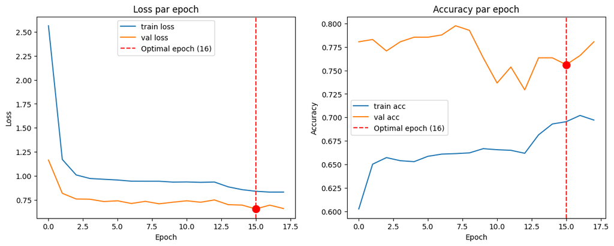

```
CPU times: total: 172 ms
Wall time: 185 ms
```

```python
%%time

def evaluation(p_history):
    # Epoch optimal (val_loss minimal)
    val_loss = p_history.history['val_loss']
    optimal_epoch = np.argmin(val_loss)
    optimal_val_loss = val_loss[optimal_epoch]
    print(f"Epoch optimal détecté : {optimal_epoch + 1} avec val_loss = {optimal_val_loss:.4f}")

    # Tracer loss et accuracy avec repère
    plt.figure(figsize=(14,5))

    # Loss
    plt.subplot(1,2,1)
    plt.plot(p_history.history['loss'], label='train loss')
    plt.plot(p_history.history['val_loss'], label='val loss')
    plt.axvline(optimal_epoch, color='r', linestyle='--', label=f'Optimal epoch ({optimal_epoch + 1})')
    plt.scatter(optimal_epoch, optimal_val_loss, color='red', s=100, zorder=5)
    plt.xlabel('Epoch')
    plt.ylabel('Loss')
    plt.title('Loss par epoch')
    plt.legend()

    # Accuracy
    plt.subplot(1,2,2)
    plt.plot(p_history.history['accuracy'], label='train acc')
    plt.plot(p_history.history['val_accuracy'], label='val acc')
    plt.axvline(optimal_epoch, color='r', linestyle='--', label=f'Optimal epoch ({optimal_epoch + 1})')
    plt.scatter(optimal_epoch, p_history.history['val_accuracy'][optimal_epoch], color='red', s=100, zorder=5)
    plt.xlabel('Epoch')
    plt.ylabel('Accuracy')
    plt.title('Accuracy par epoch')
    plt.legend()

    plt.show()

evaluation(history_frozen)
```

```
13/13 ━━━━━━━━━━━━━━━━━━━━ 3s 209ms/step
```

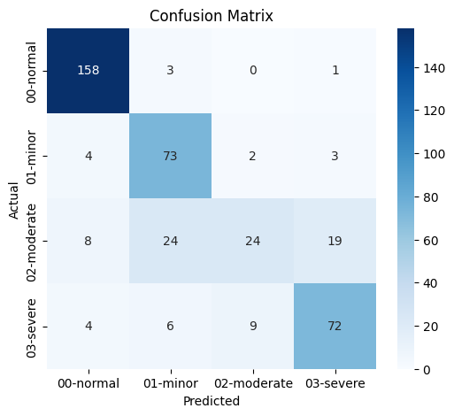

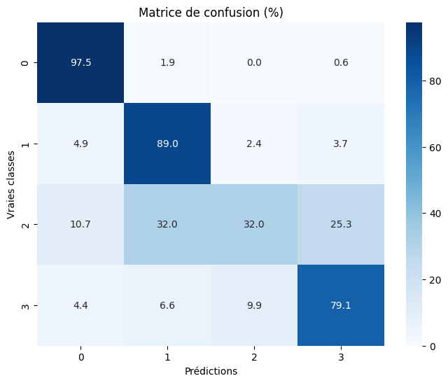

```
📄 Rapport de classification détaillé :

              precision    recall  f1-score   support

   00-normal      0.908     0.975     0.940       162
    01-minor      0.689     0.890     0.777        82
 02-moderate      0.686     0.320     0.436        75
   03-severe      0.758     0.791     0.774        91

    accuracy                          0.798       410
   macro avg      0.760     0.744     0.732       410
weighted avg      0.790     0.798     0.779       410

CPU times: total: 23 s
Wall time: 3.46 s
```

```python
%%time
# Matrice de confusion

def matrice_confusion(p_model, p_dataset):
    y_val = np.concatenate([y for x, y in p_dataset], axis=0)
    y_val = np.argmax(y_val, axis=1)
    y_pred_probs = p_model.predict(p_dataset)
    y_pred_classes = np.argmax(y_pred_probs, axis=1)

    cm = confusion_matrix(y_val, y_pred_classes)
    plt.figure(figsize=(6,5))
    sns.heatmap(cm, annot=True, fmt='d', cmap='Blues', xticklabels=class_names, yticklabels=class_names)
    plt.xlabel('Predicted')
    plt.ylabel('Actual')
    plt.title('Confusion Matrix')
    plt.show()

    # Normalisation par ligne (chaque ligne = 100%)
    cm_norm = cm.astype('float') / cm.sum(axis=1, keepdims=True)

    # Conversion en pourcentage
    cm_percent = cm_norm * 100

    # Affichage
    plt.figure(figsize=(8,6))
    sns.heatmap(cm_percent,
                annot=True,
                fmt=".1f",
                cmap="Blues")

    plt.xlabel('Prédictions')
    plt.ylabel('Vraies classes')
    plt.title('Matrice de confusion (%)')

    plt.show()

    # Rapport de classification
    print("\n📄 Rapport de classification détaillé :\n")
    print(classification_report(y_val, y_pred_classes, target_names=class_names, digits=3))


matrice_confusion(model_frozen, val_ds_prepared)
```

Fine-Tuning

Dans cette étape on va dégeler une partie des couches du modèle et l'entrainer en gardant un coefficiant de correction des poids du modèle initial très bas pour ne pas perturber le pré-entrainement initial mais en applicant quand même de petites corrections correspondant à nos données propres.

# Fine-Tuning

```python
%%time

# Évaluation AVANT fine-tuning
print("📈 Performance AVANT fine-tuning :")
results_before = model_frozen.evaluate(val_ds_prepared, verbose=0)
print(f"  - Accuracy : {results_before[1]*100:.2f}%")
print(f"  - Loss     : {results_before[0]:.4f}\n")

# clone du modèle avec ses poids
# model_finetuned = clone_model(model_frozen)
# model_finetuned.set_weights(model_frozen.get_weights())

# Dégeler le base_model
base_model.trainable = True

# Geler seulement les 100 premières couches
fine_tune_at = 100

for i, layer in enumerate(base_model.layers):
    if i < fine_tune_at:
        layer.trainable = False
    else:
        layer.trainable = True

print(f"📊 Configuration du dégel :")
print(f"  - Couches frozen  : {fine_tune_at}")
print(f"  - Couches unfrozen: {len(base_model.layers) - fine_tune_at}")

# Compter les paramètres
trainable_count = sum([tf.size(w).numpy() for w in model_frozen.trainable_weights])
non_trainable_count = sum([tf.size(w).numpy() for w in model_frozen.non_trainable_weights])
total = trainable_count + non_trainable_count

print(f"  - Paramètres entraînables : {trainable_count:,} ({trainable_count/total*100:.1f}%)")
print(f"  - Paramètres frozen       : {non_trainable_count:,}\n")

# Recompiler avec un LR très faible
FINE_TUNE_LR = 1e-5  # LR très faible

model_frozen.compile(
    optimizer=optimizers.Adam(learning_rate=FINE_TUNE_LR),
    loss='categorical_crossentropy',
    metrics=['accuracy', keras.metrics.TopKCategoricalAccuracy(k=2, name='top2_accuracy')]
)

# Le modèle fine-tuned est le modèle frozen modifié
model_finetuned = model_frozen

print_layers(model_finetuned)

print(f"✅ Modèle recompilé avec LR = {FINE_TUNE_LR}")
print("\n💡 Le modèle va continuer depuis les poids déjà appris.")

# Vérification immédiate
print("\n🔍 Vérification immédiate :")
results_after_compile = model_finetuned.evaluate(val_ds_prepared, verbose=0)
print(f"  - Accuracy : {results_after_compile[1]*100:.2f}%")
print(f"  - Loss     : {results_after_compile[0]:.4f}")

if abs(results_after_compile[1] - results_before[1]) < 0.01:
    print(f"\n  ✅ Parfait ! Les poids sont préservés ({results_after_compile[1]*100:.1f}%)")
else:
    print(f"\n  ⚠️  Les performances ont changé après recompilation")
```

```
📈 Performance AVANT fine-tuning :
  - Accuracy : 79.76%
  - Loss     : 0.7329

📊 Configuration du dégel :
  - Couches frozen  : 100
  - Couches unfrozen: 55
  - Paramètres entraînables : 2,190,404 (84.7%)
  - Paramètres frozen       : 396,544

    1. input_layer_1                            | Output: (None, 224, 224, 3)            | Trainable: True
    2. mobilenetv2_1.00_224                     | Output: (None, 1280)                   | Trainable: True
    2.    1. input_layer                              | Output: (None, 224, 224, 3)            | Trainable: False
    2.    2. Conv1                                    | Output: (None, 112, 112, 32)           | Trainable: False
    2.    3. bn_Conv1                                 | Output: (None, 112, 112, 32)           | Trainable: False
    2.    4. Conv1_relu                               | Output: (None, 112, 112, 32)           | Trainable: False
    2.    5. expanded_conv_depthwise                  | Output: (None, 112, 112, 32)           | Trainable: False
    2.    6. expanded_conv_depthwise_BN               | Output: (None, 112, 112, 32)           | Trainable: False
    2.    7. expanded_conv_depthwise_relu             | Output: (None, 112, 112, 32)           | Trainable: False
    2.    8. expanded_conv_project                    | Output: (None, 112, 112, 16)           | Trainable: False
    2.    9. expanded_conv_project_BN                 | Output: (None, 112, 112, 16)           | Trainable: False
    2.   10. block_1_expand                           | Output: (None, 112, 112, 96)           | Trainable: False
    2.   11. block_1_expand_BN                        | Output: (None, 112, 112, 96)           | Trainable: False
    2.   12. block_1_expand_relu                      | Output: (None, 112, 112, 96)           | Trainable: False
    2.   13. block_1_pad                              | Output: (None, 113, 113, 96)           | Trainable: False
    2.   14. block_1_depthwise                        | Output: (None, 56, 56, 96)             | Trainable: False
    2.   15. block_1_depthwise_BN                     | Output: (None, 56, 56, 96)             | Trainable: False
    2.   16. block_1_depthwise_relu                   | Output: (None, 56, 56, 96)             | Trainable: False
    2.   17. block_1_project                          | Output: (None, 56, 56, 24)             | Trainable: False
    2.   18. block_1_project_BN                       | Output: (None, 56, 56, 24)             | Trainable: False
    2.   19. block_2_expand                           | Output: (None, 56, 56, 144)            | Trainable: False
    2.   20. block_2_expand_BN                        | Output: (None, 56, 56, 144)            | Trainable: False
    2.   21. block_2_expand_relu                      | Output: (None, 56, 56, 144)            | Trainable: False
    2.   22. block_2_depthwise                        | Output: (None, 56, 56, 144)            | Trainable: False
    2.   23. block_2_depthwise_BN                     | Output: (None, 56, 56, 144)            | Trainable: False
    2.   24. block_2_depthwise_relu                   | Output: (None, 56, 56, 144)            | Trainable: False
    2.   25. block_2_project                          | Output: (None, 56, 56, 24)             | Trainable: False
    2.   26. block_2_project_BN                       | Output: (None, 56, 56, 24)             | Trainable: False
    2.   27. block_2_add                              | Output: (None, 56, 56, 24)             | Trainable: False
    2.   28. block_3_expand                           | Output: (None, 56, 56, 144)            | Trainable: False
```

[output cut: 127 more lines]

```
    3. dropout                                  | Output: (None, 1280)                   | Trainable: True
    4. dense                                    | Output: (None, 256)                    | Trainable: True
    5. dropout_1                                | Output: (None, 256)                    | Trainable: True
    6. dense_1                                  | Output: (None, 4)                      | Trainable: True
✅ Modèle recompilé avec LR = 1e-05

💡 Le modèle va continuer depuis les poids déjà appris.

🔍 Vérification immédiate :
  - Accuracy : 79.76%
  - Loss     : 0.7329

  ✅ Parfait ! Les poids sont préservés (79.8%)
CPU times: total: 43.2 s
Wall time: 5.22 s
```

# Entraînement du modèle fine-tuned

```python
%%time

print("🚀 Fine-tuning du modèle...\n")
print("⚠️  Le modèle continue depuis les poids frozen déjà entraînés\n")

# Callbacks pour fine-tuning
early_stopping_ft = callbacks.EarlyStopping(
    monitor='val_accuracy',
    patience=20,  # Beaucoup de patience
    restore_best_weights=True,
    mode='max',
    verbose=1
)

reduce_lr_ft = callbacks.ReduceLROnPlateau(
    monitor='val_loss',
    factor=0.5,
    patience=7,
    min_lr=1e-8,
    verbose=1
)

checkpoint_ft = callbacks.ModelCheckpoint(
    'best_model_finetuned.keras',
    monitor='val_accuracy',
    save_best_only=True,
    mode='max',
    verbose=0
)

# Entraînement
EPOCHS_FINETUNE = 50

print(f"Entraînement pour {EPOCHS_FINETUNE} epochs maximum...\n")

history_finetuned = model_finetuned.fit(
    train_ds_prepared,
    validation_data=val_ds_prepared,
    epochs=EPOCHS_FINETUNE,
    callbacks=[early_stopping_ft, reduce_lr_ft, checkpoint_ft],
    verbose=1
)

print("\n✅ Fine-tuning terminé !")
print(f"   Nombre d'epochs effectués : {len(history_finetuned.history['loss'])}")

# Meilleures performances
best_val_acc = max(history_finetuned.history['val_accuracy'])
best_epoch = history_finetuned.history['val_accuracy'].index(best_val_acc) + 1
print(f"   Meilleure val_accuracy : {best_val_acc*100:.2f}% (epoch {best_epoch})")

# Comparaison
frozen_best = max(history_frozen.history['val_accuracy'])
improvement = (best_val_acc - frozen_best) * 100
print(f"\n📊 Amélioration vs Frozen : {improvement:+.2f} points de pourcentage")
print(f"   - Frozen    : {frozen_best*100:.2f}%")
print(f"   - Fine-tuned: {best_val_acc*100:.2f}%")
```

```
🚀 Fine-tuning du modèle...

⚠️  Le modèle continue depuis les poids frozen déjà entraînés

Entraînement pour 50 epochs maximum...

362/362 ━━━━━━━━━━━━━━━━━━━━ 95s 246ms/step - accuracy: 0.6431 - loss: 0.9717 - top2_accuracy: 0.8711 - val_accuracy: 0.7439 - val_loss: 0.7770 - val_top2_accuracy: 0.9073 - learning_rate: 1.0000e-05
362/362 ━━━━━━━━━━━━━━━━━━━━ 90s 247ms/step - accuracy: 0.7070 - loss: 0.8227 - top2_accuracy: 0.9183 - val_accuracy: 0.7756 - val_loss: 0.7194 - val_top2_accuracy: 0.9293 - learning_rate: 1.0000e-05
362/362 ━━━━━━━━━━━━━━━━━━━━ 90s 248ms/step - accuracy: 0.7437 - loss: 0.7402 - top2_accuracy: 0.9386 - val_accuracy: 0.8000 - val_loss: 0.6524 - val_top2_accuracy: 0.9439 - learning_rate: 1.0000e-05
362/362 ━━━━━━━━━━━━━━━━━━━━ 91s 251ms/step - accuracy: 0.7780 - loss: 0.6678 - top2_accuracy: 0.9547 - val_accuracy: 0.8098 - val_loss: 0.5982 - val_top2_accuracy: 0.9561 - learning_rate: 1.0000e-05
362/362 ━━━━━━━━━━━━━━━━━━━━ 91s 250ms/step - accuracy: 0.8038 - loss: 0.6133 - top2_accuracy: 0.9638 - val_accuracy: 0.8098 - val_loss: 0.5592 - val_top2_accuracy: 0.9683 - learning_rate: 1.0000e-05
362/362 ━━━━━━━━━━━━━━━━━━━━ 91s 252ms/step - accuracy: 0.8278 - loss: 0.5617 - top2_accuracy: 0.9768 - val_accuracy: 0.8073 - val_loss: 0.5471 - val_top2_accuracy: 0.9732 - learning_rate: 1.0000e-05
362/362 ━━━━━━━━━━━━━━━━━━━━ 90s 248ms/step - accuracy: 0.8551 - loss: 0.5075 - top2_accuracy: 0.9822 - val_accuracy: 0.8073 - val_loss: 0.5506 - val_top2_accuracy: 0.9780 - learning_rate: 1.0000e-05
362/362 ━━━━━━━━━━━━━━━━━━━━ 90s 250ms/step - accuracy: 0.8759 - loss: 0.4644 - top2_accuracy: 0.9890 - val_accuracy: 0.8098 - val_loss: 0.5411 - val_top2_accuracy: 0.9805 - learning_rate: 1.0000e-05
362/362 ━━━━━━━━━━━━━━━━━━━━ 90s 249ms/step - accuracy: 0.8976 - loss: 0.4188 - top2_accuracy: 0.9926 - val_accuracy: 0.8024 - val_loss: 0.5455 - val_top2_accuracy: 0.9805 - learning_rate: 1.0000e-05
362/362 ━━━━━━━━━━━━━━━━━━━━ 90s 249ms/step - accuracy: 0.9176 - loss: 0.3748 - top2_accuracy: 0.9962 - val_accuracy: 0.8098 - val_loss: 0.5391 - val_top2_accuracy: 0.9854 - learning_rate: 1.0000e-05
362/362 ━━━━━━━━━━━━━━━━━━━━ 91s 251ms/step - accuracy: 0.9356 - loss: 0.3360 - top2_accuracy: 0.9973 - val_accuracy: 0.8000 - val_loss: 0.5551 - val_top2_accuracy: 0.9780 - learning_rate: 1.0000e-05
362/362 ━━━━━━━━━━━━━━━━━━━━ 91s 250ms/step - accuracy: 0.9521 - loss: 0.2970 - top2_accuracy: 0.9983 - val_accuracy: 0.8000 - val_loss: 0.5504 - val_top2_accuracy: 0.9805 - learning_rate: 1.0000e-05
362/362 ━━━━━━━━━━━━━━━━━━━━ 91s 251ms/step - accuracy: 0.9647 - loss: 0.2655 - top2_accuracy: 0.9986 - val_accuracy: 0.7927 - val_loss: 0.5581 - val_top2_accuracy: 0.9780 - learning_rate: 1.0000e-05
362/362 ━━━━━━━━━━━━━━━━━━━━ 91s 251ms/step - accuracy: 0.9765 - loss: 0.2340 - top2_accuracy: 0.9990 - val_accuracy: 0.7976 - val_loss: 0.5764 - val_top2_accuracy: 0.9732 - learning_rate: 1.0000e-05
362/362 ━━━━━━━━━━━━━━━━━━━━ 91s 251ms/step - accuracy: 0.9836 - loss: 0.2091 - top2_accuracy: 0.9996 - val_accuracy: 0.8122 - val_loss: 0.5963 - val_top2_accuracy: 0.9732 - learning_rate: 1.0000e-05
362/362 ━━━━━━━━━━━━━━━━━━━━ 91s 253ms/step - accuracy: 0.9888 - loss: 0.1878 - top2_accuracy: 0.9998 - val_accuracy: 0.7976 - val_loss: 0.5980 - val_top2_accuracy: 0.9732 - learning_rate: 1.0000e-05
362/362 ━━━━━━━━━━━━━━━━━━━━ 0s 246ms/step - accuracy: 0.9912 - loss: 0.1774 - top2_accuracy: 0.9998
Epoch 17: ReduceLROnPlateau reducing learning rate to 4.999999873689376e-06.
362/362 ━━━━━━━━━━━━━━━━━━━━ 91s 252ms/step - accuracy: 0.9926 - loss: 0.1718 - top2_accuracy: 0.9997 - val_accuracy: 0.7927 - val_loss: 0.6233 - val_top2_accuracy: 0.9732 - learning_rate: 1.0000e-05
362/362 ━━━━━━━━━━━━━━━━━━━━ 91s 252ms/step - accuracy: 0.9951 - loss: 0.1554 - top2_accuracy: 0.9998 - val_accuracy: 0.7927 - val_loss: 0.6400 - val_top2_accuracy: 0.9732 - learning_rate: 5.0000e-06
```

[output cut: 33 more lines]

Evaluation du modèle entrainé en Fine-Tuning

```
Epoch optimal détecté : 10 avec val_loss = 0.5391
```

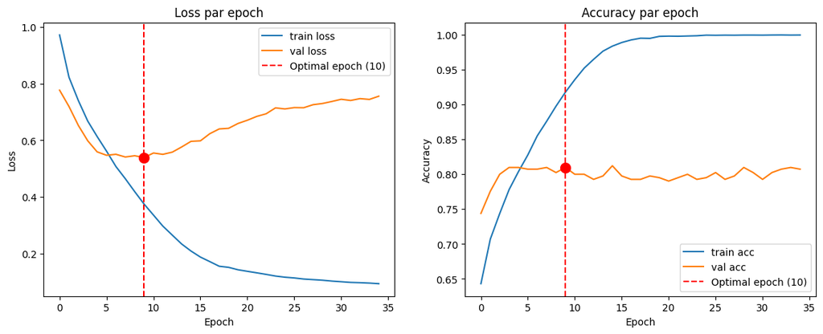

```
CPU times: total: 109 ms
Wall time: 119 ms
```

```python
%%time

evaluation(history_finetuned)
```

```
13/13 ━━━━━━━━━━━━━━━━━━━━ 3s 189ms/step
```

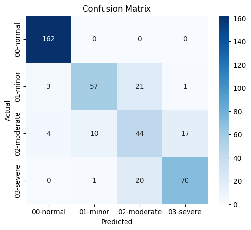

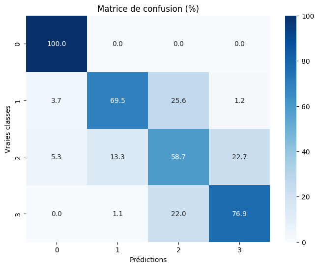

```
📄 Rapport de classification détaillé :

              precision    recall  f1-score   support

   00-normal      0.959     1.000     0.979       162
    01-minor      0.838     0.695     0.760        82
 02-moderate      0.518     0.587     0.550        75
   03-severe      0.795     0.769     0.782        91

    accuracy                          0.812       410
   macro avg      0.777     0.763     0.768       410
weighted avg      0.818     0.812     0.813       410

CPU times: total: 23.8 s
Wall time: 3.09 s
```

```python
%%time

matrice_confusion(model_finetuned, val_ds_prepared)
```

Sauvegarde de cette version du modèle

```python
%%time

# Sauvegarde du modèle

# Sauvegarder au format Keras (.keras)
model_path = 'mobilenetv2_test1_finetuned.keras'
model_finetuned.save(model_path)

with open("mobilenetv2_test1_finetuned_class_names.json", "w") as f:
    json.dump(class_names, f)

print(f"\n✅ Modèle sauvegardé : {model_path}")
print(f"   Taille du fichier : {os.path.getsize(model_path) / (1024**2):.1f} MB")

# Sauvegarder aussi au format h5 (legacy)
model_h5_path = 'mobilenetv2_test1_finetuned.h5'
model_finetuned.save(model_h5_path)
print(f"\n✅ Modèle également sauvegardé en .h5 : {model_h5_path}")


# Pour recharger le modèle
# loaded_model = keras.models.load_model(model_path)
```

```
WARNING:absl:You are saving your model as an HDF5 file via `model.save()` or `keras.saving.save_model(model)`. This file format is considered legacy. We recommend using instead the native Keras format, e.g. `model.save('my_model.keras')` or `keras.saving.save_model(model, 'my_model.keras')`.
```

```
✅ Modèle sauvegardé : mobilenetv2_test1_finetuned.keras
   Taille du fichier : 27.2 MB

✅ Modèle également sauvegardé en .h5 : mobilenetv2_test1_finetuned.h5
CPU times: total: 344 ms
Wall time: 368 ms
```

Test de cette version du modèle

# Test

```python
%%time

# Fonction de prédiction

def predict_image(model, image_path, class_names):

    # Charger et prétraiter l'image
    img = load_img(image_path, target_size=(224, 224))
    img_array = tf.keras.preprocessing.image.img_to_array(img)
    img_array = tf.expand_dims(img_array, 0)  # Ajouter dimension batch
    img_array = preprocess_input(img_array)  # Normalisation MobileNetV2

    # Prédire
    predictions = model.predict(img_array, verbose=0)
    predicted_class_idx = np.argmax(predictions[0])
    confidence = predictions[0][predicted_class_idx]

    # Top 3 prédictions
    top3_idx = np.argsort(predictions[0])[-3:][::-1]

    return {
        'predicted_class': class_names[predicted_class_idx],
        'confidence': confidence,
        'all_probabilities': predictions[0],
        'top3': [(class_names[i], predictions[0][i]) for i in top3_idx]
    }

print("✅ Fonction de prédiction créée !")
```

```
✅ Fonction de prédiction créée !
CPU times: total: 0 ns
Wall time: 0 ns
```

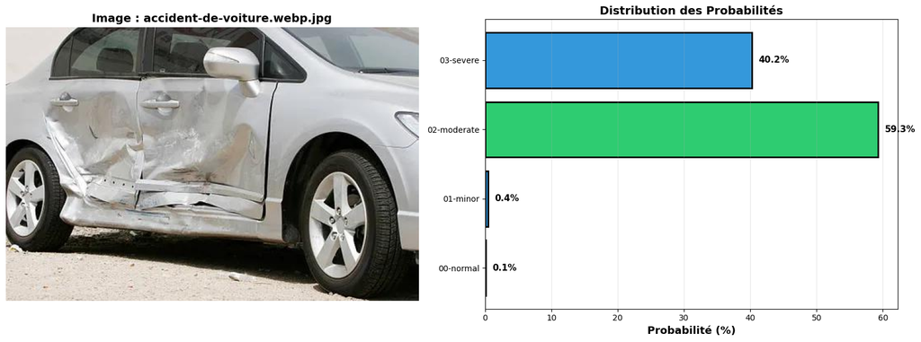

```
🔍 Analyse de la prédiction :
  - Classe prédite : 02-moderate
  - Confiance      : 59.29%

  - Top 3 prédictions :
    1. 02-moderate     : 59.29%
    2. 03-severe       : 40.20%
    3. 01-minor        : 0.43%
CPU times: total: 1.2 s
Wall time: 1.28 s
```

```python
%%time

model_path = 'mobilenetv2_test1_finetuned.keras'
loaded_model = keras.models.load_model(model_path)
class_names = ["00-normal", "01-minor", "02-moderate", "03-severe"]

# Visualisation des probabilités pour une image

from PIL import Image

# Prendre une image spécifique
sample_image_path = "C:/Users/huber_otpq54a/OneDrive/Documents/Formation/IA/Developpement/Projets/Deep_Learning/Test/accident-de-voiture.webp"

im = Image.open(sample_image_path).convert("RGB")
sample_image_path = sample_image_path + ".jpg"
im.save(sample_image_path, "JPEG")

result = predict_image(loaded_model, sample_image_path, class_names)

# Visualiser
fig, axes = plt.subplots(1, 2, figsize=(16, 6))

# Image
img = plt.imread(sample_image_path)
axes[0].imshow(img)
axes[0].axis('off')
axes[0].set_title(f"Image : {str(Path(sample_image_path).name)}", fontsize=14, fontweight='bold')

# Probabilités
probs = result['all_probabilities'] * 100
colors = ['#2ecc71' if i == np.argmax(probs) else '#3498db' for i in range(len(probs))]

bars = axes[1].barh(class_names, probs, color=colors, edgecolor='black', linewidth=2)
axes[1].set_xlabel('Probabilité (%)', fontsize=13, fontweight='bold')
axes[1].set_title('Distribution des Probabilités', fontsize=14, fontweight='bold')
axes[1].grid(alpha=0.3, axis='x')

# Ajouter les valeurs
for bar, prob in zip(bars, probs):
    width = bar.get_width()
    axes[1].text(width + 1, bar.get_y() + bar.get_height()/2.,
                f'{prob:.1f}%',
                ha='left', va='center', fontsize=11, fontweight='bold')

plt.tight_layout()
plt.show()

print(f"\n🔍 Analyse de la prédiction :")
print(f"  - Classe prédite : {result['predicted_class']}")
print(f"  - Confiance      : {result['confidence']*100:.2f}%")
print(f"\n  - Top 3 prédictions :")
for i, (cls, prob) in enumerate(result['top3'], 1):
    print(f"    {i}. {cls:15s} : {prob*100:.2f}%")
```